# Macroscale watershed science

Hacking Limnology 2023

## MacroSheds: long-term watershed ecosystem studies, harmonized

### Goals

- enable calculation of input/output solute fluxes from diverse watersheds
- lower barriers through data harmonization and visualization
- investigate:
  - variation in magnitude, timing, form of N exports
  - broad effects of watershed acidification
  - variation in mineral weathering
  - watershed sensitivity to climate change

### Components

- macrosheds.org
- [The dataset](https://portal.edirepository.org/nis/mapbrowse?scope=edi&identifier=1262)
- [R package](https://github.com/MacroSHEDS/macrosheds)
- [All project code](https://github.com/MacroSHEDS)

### Terms

- site: an individual gauging station or stream sampling location and its watershed
- domain: one or more sites under common management
- network: one or more domains under common funding/leadership
- flux: solute mass normalized to watershed area, over time (kg/ha/d)

## Related resources

- [GEMStat](https://gemstat.org/) - global water quality database
- [GLORICH](https://www.geo.uni-hamburg.de/en/geologie/forschung/aquatische-geochemie/glorich.html) - global river chemistry database
- [Water Quality Portal (WQP)](https://www.waterqualitydata.us/) - USA water quality database
- [Global River Water Quality Archive](https://essd.copernicus.org/articles/13/5483/2021/) - subset of: GEMStat + GLORICH + WQP + CESI (Canada) + Waterbase (Europe)
- CAMELS - Catchment Attributes and MEteorology for Large-sample Studies
  - [USA](https://gdex.ucar.edu/dataset/camels.html)
  - [Australia](https://www.webofscience.com/wos/woscc/full-record/WOS:000683780500004?SID=USW2EC0D4DYFZoLYt17MtaFngvTOg)
  - [Brazil](https://www.webofscience.com/wos/woscc/full-record/WOS:000569420300002?SID=USW2EC0D4DYFZoLYt17MtaFngvTOg)
  - [Chile](https://www.webofscience.com/wos/woscc/full-record/WOS:000449995800002?SID=USW2EC0D4DYFZoLYt17MtaFngvTOg)
  - [Great Britain](https://www.webofscience.com/wos/woscc/full-record/WOS:000580860000002?SID=USW2EC0D4DYFZoLYt17MtaFngvTOg)
- [Caravan](https://zenodo.org/record/7944025) - subset of: CAMELS + HYSETS (N. Am.) + LamaH-CE (central Europe)
- [CAMELS-Chem](https://hess.copernicus.org/preprints/hess-2022-81/) - chemistry for CAMELS-US

## Introduction

### Setup

```r
suppressPackageStartupMessages(library(tidyverse))
library(macrosheds)
project_root <- "~/macrosheds_workshop"
```

### Retrieval

```r
?ms_download_ws_attr
?ms_load_product

ms_download_ws_attr(project_root, dataset = "summaries")
```

```
## watershed_summaries.feather successfully downloaded to ~/macrosheds_workshop
```

```r
ws_smry <- ms_load_product(project_root, prodname = "ws_attr_summaries")
```

- watershed summary attribute definitions: https://portal.edirepository.org/nis/metadataviewer?packageid=edi.1262.1 -> Data Entities -> ws_attr_summaries.csv
- two-letter prefixes: variable_category_codes_ws_attr.csv, variable_data_source_codes_ws_attr.csv

### Principal component analysis of watershed summary attributes

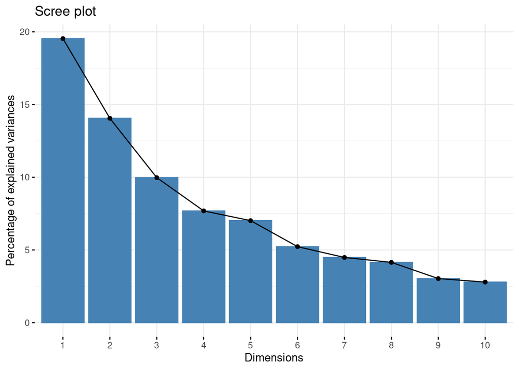

```r
suppressPackageStartupMessages(library(factoextra))

pca_data <- ws_smry %>%
    select(where( ~sum(is.na(.)) / length(.) < 0.3)) %>% #drop columns with >= 30% missing values
    drop_na()                                            #drop rows with any missing values

domains <- pca_data$domain

pca_data <- pca_data %>%
    select(-site_code, -domain, -network) %>%
    select(where(~sd(., na.rm = TRUE) != 0)) %>%         #drop columns with no variance
    as.matrix()

smry_categories <- substr(colnames(pca_data), 1, 1)
category_map <- c('c' = 'climate', 'h' = 'hydrology', 'l' = 'landcover',
                  'p' = 'parentmat', 't' = 'terrain', 'v' = 'vegetation',
                  'w' = 'ws area')
smry_categories <- factor(category_map[match(smry_categories, names(category_map))])

pca <- prcomp(pca_data, center = TRUE, scale. = TRUE)

fviz_eig(pca)
```

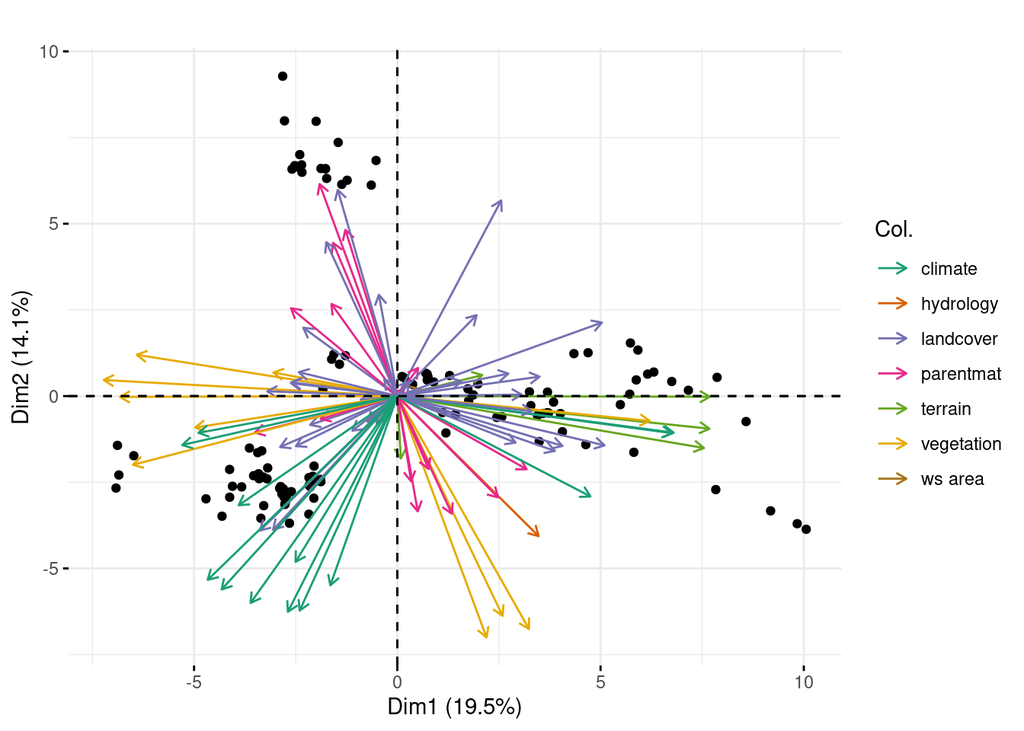

```r
fviz_pca_biplot(pca, geom.var = "arrow", geom.ind = "point", title = "",
                col.var = smry_categories, palette = 'Dark2')
```

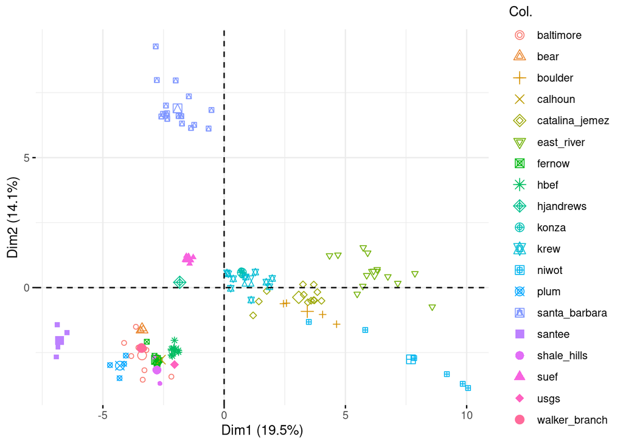

```r
fviz_pca_biplot(pca, geom.var = "", geom.ind = "point", title = "",
                col.ind = as.factor(domains))
```